# COVID-19 project report 2

Zian ZHUANG

## Q4.6

### (a)

Estimate the survival (infection-free) functions and their standard errors for the chlorhexidine and povidone-iodine groups.

```r
data(burn)
df_p <- burn[which(burn$Z1==0),]
df_c <- burn[which(burn$Z1==1),]

#povidone-iodine group
fit_p <- survfit(Surv(T3, D3) ~ 1, data = df_p)
summary(fit_p)
```

```
## Call: survfit(formula = Surv(T3, D3) ~ 1, data = df_p)
##
##  time n.risk n.event survival std.err lower 95% CI upper 95% CI
##     1     70       1    0.986  0.0142        0.958        1.000
##     3     69       3    0.943  0.0277        0.890        0.999
##     4     66       4    0.886  0.0380        0.814        0.963
##     5     62       1    0.871  0.0400        0.796        0.953
##     6     60       2    0.842  0.0436        0.761        0.932
##     7     58       3    0.799  0.0481        0.710        0.899
##     8     53       1    0.784  0.0495        0.693        0.887
##     9     50       2    0.752  0.0522        0.657        0.862
##    10     47       1    0.736  0.0535        0.639        0.849
##    11     44       2    0.703  0.0561        0.601        0.822
##    13     40       1    0.685  0.0574        0.582        0.808
##    19     33       1    0.665  0.0593        0.558        0.791
##    21     30       1    0.642  0.0613        0.533        0.774
##    23     27       1    0.619  0.0635        0.506        0.756
##    32     18       1    0.584  0.0686        0.464        0.735
##    44      8       1    0.511  0.0910        0.361        0.725
##    47      6       1    0.426  0.1086        0.258        0.702
##    51      4       1    0.320  0.1231        0.150        0.680
```

```r
#chlorhexidine group
fit_c <- survfit(Surv(T3, D3) ~ 1, data = df_c)
summary(fit_c)
```

```
## Call: survfit(formula = Surv(T3, D3) ~ 1, data = df_c)
##
##  time n.risk n.event survival std.err lower 95% CI upper 95% CI
##     2     84       3    0.964  0.0202        0.925        1.000
##     3     81       1    0.952  0.0232        0.908        0.999
##     4     80       1    0.940  0.0258        0.891        0.992
##     5     79       5    0.881  0.0353        0.814        0.953
##     8     73       1    0.869  0.0369        0.800        0.944
##    10     70       1    0.856  0.0384        0.784        0.935
##    11     68       1    0.844  0.0398        0.769        0.926
##    14     57       1    0.829  0.0418        0.751        0.915
##    16     50       1    0.812  0.0441        0.730        0.904
##    17     47       2    0.778  0.0485        0.688        0.879
##    18     41       2    0.740  0.0531        0.643        0.852
##    42      9       1    0.658  0.0907        0.502        0.862
```

### (b)

Estimate the cumulative hazard rates and their standard errors for the chlorhexidine and povidone-iodine groups. Plot these estimates. Does it appear that the two cumulative hazard rates are proportional to each other?

```r
# povidone-iodine group
H.est.p <- cumsum(fit_p$n.event/fit_p$n.risk)
Var.est.p <- cumsum(fit_p$n.event/fit_p$n.risk^2)
data.frame(H.est=H.est.p, SE.est=sqrt(Var.est.p))
```

```
##         H.est     SE.est
## 1  0.01428571 0.01428571
## 2  0.05776398 0.02888254
## 3  0.11837004 0.04186257
## 4  0.13449907 0.04486224
## 5  0.16783240 0.05067718
## 6  0.21955654 0.05882152
## 7  0.23842446 0.06177354
## 8  0.27842446 0.06794093
## 9  0.29970106 0.07119455
## 10 0.34515561 0.07811352
## 11 0.34515561 0.07811352
## 12 0.37015561 0.08201659
## 13 0.37015561 0.08201659
## 14 0.37015561 0.08201659
```

[output cut: 23 more lines]

```r
# chlorhexidine group
H.est.c <- cumsum(fit_c$n.event/fit_c$n.risk)
Var.est.c <- cumsum(fit_c$n.event/fit_c$n.risk^2)
data.frame(H.est=H.est.c, SE.est=sqrt(Var.est.c))
```

```
##         H.est     SE.est
## 1  0.03571429 0.02061965
## 2  0.04805996 0.02403302
## 3  0.06055996 0.02708940
## 4  0.12385110 0.03917894
## 5  0.12385110 0.03917894
## 6  0.13754973 0.04150472
## 7  0.13754973 0.04150472
## 8  0.15183545 0.04389446
## 9  0.16654133 0.04629240
## 10 0.16654133 0.04629240
## 11 0.16654133 0.04629240
## 12 0.18408519 0.04950529
## 13 0.18408519 0.04950529
## 14 0.20408519 0.05339264
```

[output cut: 22 more lines]

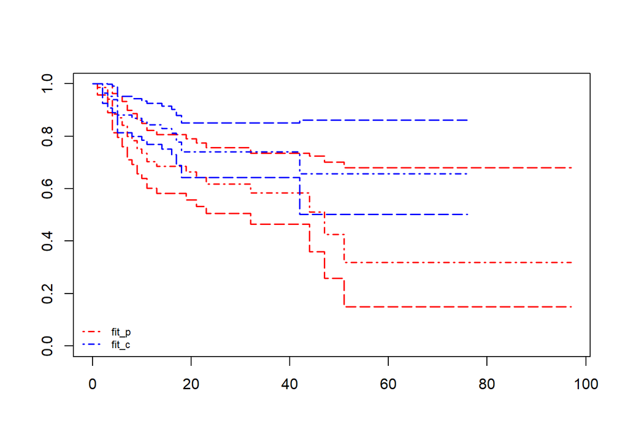

```r
# proportion
plot(fit_p, lty = 4, col = "red", lwd = 1.5)
lines(fit_c, lty = 4, col = "blue", lwd = 1.5)
legend("bottomleft", legend=
         c("fit_p",
           "fit_c"), lty=4,
       bty = "n", lwd = 1.5, cex = .7,
       col = c( "red", "blue"))
```

Since two lines crossed, we know that these two cumulative hazard rates are not proportional to each other.

### (c)

Provide estimates of the median time to infection and find 95% confidence intervals for the median time to infection for both the chlorhexidine and povidone-iodine groups using the linear, log-transformed, and arcsine formulas.

Please note that here we modified the `bc.median.ci` function.

```r
source("functions//bc_median_ci.R")
# povidone-iodine group
bc.median.ci(fit_p, type = "linear", table = T)
```

```
## $median
## [1] 47
##
## $lower
## [1] 23
##
## $upper
## [1] NA
##
## $type
## [1] "linear"
##
## $alpha
## [1] 0.05
##
## $table
##    time  surv      z
## 1     1 0.986 34.245
## 2     3 0.943 15.963
## 3     4 0.886 10.143
## 4     5 0.871  9.284
## 5     6 0.842  7.848
## 6     7 0.799  6.215
## 7     8 0.784  5.734
## 8     9 0.752  4.832
## 9    10 0.736  4.417
## 10   11 0.703  3.619
## 12   13 0.685  3.231
## 16   19 0.665  2.777
## 18   21 0.642  2.324
## 19   23 0.619  1.869
## 25   32 0.584  1.228
## 31   44 0.511  0.123
## 33   47 0.426 -0.681
## 34   51 0.320 -1.467
```

```r
bc.median.ci(fit_p, type = "log", table = T)
```

```
## $median
## [1] 47
##
## $lower
## [1] 23
##
## $upper
## [1] NA
##
## $type
## [1] "log"
##
## $alpha
## [1] 0.05
##
## $table
##    time  surv      z
## 1     1 0.986  3.875
## 2     3 0.943  4.932
## 3     4 0.886  4.925
## 4     5 0.871  4.846
## 5     6 0.842  4.625
## 6     7 0.799  4.205
## 7     8 0.784  4.035
## 8     9 0.752  3.650
## 9    10 0.736  3.443
## 10   11 0.703  2.988
## 12   13 0.685  2.739
## 16   19 0.665  2.422
## 18   21 0.642  2.082
## 19   23 0.619  1.718
## 25   32 0.584  1.164
## 31   44 0.511  0.123
## 33   47 0.426 -0.696
## 34   51 0.320 -1.476
```

```r
bc.median.ci(fit_p, type = "asin", table = T)
```

```
## $median
## [1] 47
##
## $lower
## [1] 23
##
## $upper
## [1] NA
##
## $type
## [1] "asin"
##
## $alpha
## [1] 0.05
##
## $table
##    time  surv      z
## 1     1 0.986 11.137
## 2     3 0.943  9.103
## 3     4 0.886  7.372
## 4     5 0.871  7.006
## 5     6 0.842  6.300
## 6     7 0.799  5.341
## 7     8 0.784  5.021
## 8     9 0.752  4.373
## 9    10 0.736  4.054
## 10   11 0.703  3.405
## 12   13 0.685  3.074
## 16   19 0.665  2.672
## 18   21 0.642  2.259
## 19   23 0.619  1.833
## 25   32 0.584  1.216
## 31   44 0.511  0.123
## 33   47 0.426 -0.676
## 34   51 0.320 -1.399
```

```r
# chlorhexidine group (not available)
bc.median.ci(fit_c, type = "linear", table = T)
```

```
## $median
## [1] Inf
##
## $lower
## [1] 42
##
## $upper
## [1] NA
##
## $type
## [1] "linear"
##
## $alpha
## [1] 0.05
##
## $table
##    time  surv      z
## 1     2 0.964 22.930
## 2     3 0.952 19.469
## 3     4 0.940 17.063
## 4     5 0.881 10.781
## 6     8 0.869 10.009
## 8    10 0.856  9.293
## 9    11 0.844  8.638
## 12   14 0.829  7.877
## 14   16 0.812  7.085
## 15   17 0.778  5.726
## 16   18 0.740  4.522
## 29   42 0.658  1.738
```

```r
bc.median.ci(fit_c, type = "log", table = T)
```

```
## $median
## [1] Inf
##
## $lower
## [1] 42
##
## $upper
## [1] NA
##
## $type
## [1] "log"
##
## $alpha
## [1] 0.05
##
## $table
##    time  surv     z
## 1     2 0.964 5.105
## 2     3 0.952 5.307
## 3     4 0.940 5.420
## 4     5 0.881 5.369
## 6     8 0.869 5.288
## 8    10 0.856 5.183
## 9    11 0.844 5.062
## 12   14 0.829 4.865
## 14   16 0.812 4.611
## 15   17 0.778 4.087
## 16   18 0.740 3.501
## 29   42 0.658 1.529
```

```r
bc.median.ci(fit_c, type = "asin", table = T)
```

```
## $median
## [1] Inf
##
## $lower
## [1] 42
##
## $upper
## [1] NA
##
## $type
## [1] "asin"
##
## $alpha
## [1] 0.05
##
## $table
##    time  surv      z
## 1     2 0.964 10.912
## 2     3 0.952 10.364
## 3     4 0.940  9.879
## 4     5 0.881  7.939
## 6     8 0.869  7.599
## 8    10 0.856  7.254
## 9    11 0.844  6.915
## 12   14 0.829  6.473
## 14   16 0.812  5.974
## 15   17 0.778  5.047
## 16   18 0.740  4.138
## 29   42 0.658  1.678
```

### (d)

Find 95% confidence intervals for the survival (infection-free) functions at 10 days postadmission for both the chlorhexidine and povidone-iodine groups using the log transformed and arcsine transformed formulas.

#### arcsin transformed

For povidone-iodine group

```r
source("functions//arcsin_ci.R")
arcsin.ci(fit_p, alpha = 0.05)
```

```
##    time  surv sigma lower upper
## 1     1 0.986 0.014 0.945 1.000
## 2     3 0.943 0.029 0.877 0.985
## 3     4 0.886 0.043 0.801 0.949
## 4     5 0.871 0.046 0.784 0.939
## 5     6 0.842 0.052 0.748 0.918
## 6     7 0.799 0.060 0.697 0.884
## 7     8 0.784 0.063 0.680 0.872
## 8     9 0.752 0.069 0.644 0.847
## 9    10 0.736 0.073 0.626 0.834
## 10   11 0.703 0.080 0.588 0.806
## 11   12 0.703 0.080 0.588 0.806
## 12   13 0.685 0.084 0.569 0.791
## 13   14 0.685 0.084 0.569 0.791
## 14   16 0.685 0.084 0.569 0.791
```

[output cut: 23 more lines]

we can found that 95% confidence intervals for the survival functions at 10 days is 0.736(0.626, 0.834).

For chlorhexidine group

```r
arcsin.ci(fit_c, alpha = 0.05)
```

```
##    time  surv sigma lower upper
## 1     2 0.964 0.021 0.914 0.993
## 2     3 0.952 0.024 0.897 0.987
## 3     4 0.940 0.027 0.880 0.981
## 4     5 0.881 0.040 0.804 0.941
## 5     7 0.881 0.040 0.804 0.941
## 6     8 0.869 0.042 0.789 0.932
## 7     9 0.869 0.042 0.789 0.932
## 8    10 0.856 0.045 0.774 0.923
## 9    11 0.844 0.047 0.759 0.913
## 10   12 0.844 0.047 0.759 0.913
## 11   13 0.844 0.047 0.759 0.913
## 12   14 0.829 0.050 0.740 0.903
## 13   15 0.829 0.050 0.740 0.903
## 14   16 0.812 0.054 0.719 0.891
```

[output cut: 22 more lines]

#### log transformed

Firstly, define a function to calculate

```r
log.ci <- function(surv.object, alpha = 0.05, events.only = FALSE) {

  #- Extract necessary values from survsurv.object object
  surv.est  <- surv.object$surv
  sigma     <- surv.object$std.err #This is sigma, not the SE of S(t)
  surv.time <- surv.object$time

  #- Get limits element wise
  lims <- data.frame(time = surv.object$time, surv = surv.est,  sigma = surv.object$std.err)

  theta <- exp(qnorm(1 - alpha / 2) * sigma / log(surv.est))
  lims$lower <- surv.est^(1/theta)
  lims$upper <- surv.est^(theta)

  if (events.only == TRUE) {
    return(round(lims[which(surv.object$n.censor == 0), ], 3))
  } else {
    return(round(lims, 3))
  }
}
```

For povidone-iodine group

```r
log.ci(fit_p, alpha = 0.05)
```

```
##    time  surv sigma lower upper
## 1     1 0.986 0.014 0.903 0.998
## 2     3 0.943 0.029 0.855 0.978
## 3     4 0.886 0.043 0.784 0.941
## 4     5 0.871 0.046 0.767 0.931
## 5     6 0.842 0.052 0.733 0.909
## 6     7 0.799 0.060 0.684 0.876
## 7     8 0.784 0.063 0.667 0.864
## 8     9 0.752 0.069 0.632 0.838
## 9    10 0.736 0.073 0.614 0.825
## 10   11 0.703 0.080 0.577 0.798
## 11   12 0.703 0.080 0.577 0.798
## 12   13 0.685 0.084 0.558 0.783
## 13   14 0.685 0.084 0.558 0.783
## 14   16 0.685 0.084 0.558 0.783
```

[output cut: 23 more lines]

we can found that 95% confidence intervals for the survival functions at 10 days is 0.736(0.614, 0.825).

For chlorhexidine group

```r
log.ci(fit_c, alpha = 0.05)
```

```
##    time  surv sigma lower upper
## 1     2 0.964 0.021 0.893 0.988
## 2     3 0.952 0.024 0.878 0.982
## 3     4 0.940 0.027 0.863 0.975
## 4     5 0.881 0.040 0.790 0.934
## 5     7 0.881 0.040 0.790 0.934
## 6     8 0.869 0.042 0.776 0.925
## 7     9 0.869 0.042 0.776 0.925
## 8    10 0.856 0.045 0.761 0.916
## 9    11 0.844 0.047 0.746 0.906
## 10   12 0.844 0.047 0.746 0.906
## 11   13 0.844 0.047 0.746 0.906
## 12   14 0.829 0.050 0.728 0.895
## 13   15 0.829 0.050 0.728 0.895
## 14   16 0.812 0.054 0.707 0.883
```

[output cut: 22 more lines]

we can found that 95% confidence intervals for the survival functions at 10 days is 0.856(0.761, 0.916).

### (e)

Find 95% confidence bands for the infection-free functions over the range 8–20 days postinfection for both the chlorhexidine and povidone-iodine groups using the linear, log transformed, and arcsine transformed formulas.

Please note that here we modified the `cbands.interval` function.

```r
source("functions\\conf_bands.R")
```

#### povidone-iodine

```r
#calculate critical regions first
cbands.region(fit_p, 8, 20)
```

```
## Find critical regions in Klein and Moeschberger 2nd ed. (Appendix C.3a - C.4c)
```

```
## $aL
## [1] 0.13
##
## $aU
## [1] 0.23
```

```r
#2.6299
```

linear

```r
cbands.interval(fit_p, 8, 20, crit.value=2.6299,
                alpha = 0.05, type = "linear", method = "ep")
```

```
## Returning linear-type confidence bands using ep method.
```

```
##     t  surv    se    LL    UL
## 1   8 0.784 0.063 0.654 0.914
## 2   9 0.752 0.069 0.615 0.890
## 3  10 0.736 0.073 0.596 0.877
## 4  11 0.703 0.080 0.555 0.850
## 6  13 0.685 0.084 0.534 0.836
## 10 19 0.665 0.089 0.509 0.820
```

arcsinetransformed

```r
cbands.interval(fit_p, 8, 20, crit.value=2.6299,
                alpha = 0.05, type = "asin", method = "ep")
```

```
## Returning asin-type confidence bands using ep method.
```

```
##     t  surv    se    LL    UL
## 1   8 0.784 0.063 0.642 0.898
## 2   9 0.752 0.069 0.605 0.875
## 3  10 0.736 0.073 0.586 0.863
## 4  11 0.703 0.080 0.548 0.837
## 6  13 0.685 0.084 0.527 0.824
## 10 19 0.665 0.089 0.503 0.809
```

log-transformed

```r
cbands.interval(fit_p, 8, 20, crit.value=2.6299,
                alpha = 0.05, type = "log", method = "ep")
```

```
## Returning log-type confidence bands using ep method.
```

```
##     t  surv    se    LL    UL
## 1   8 0.784 0.063 0.618 0.884
## 2   9 0.752 0.069 0.582 0.861
## 3  10 0.736 0.073 0.565 0.849
## 4  11 0.703 0.080 0.528 0.823
## 6  13 0.685 0.084 0.508 0.810
## 10 19 0.665 0.089 0.484 0.794
```

#### chlorhexidine

```r
#calculate critical regions first
cbands.region(fit_c, 8, 20)
```

```
## Find critical regions in Klein and Moeschberger 2nd ed. (Appendix C.3a - C.4c)
```

```
## $aL
## [1] 0.06
##
## $aU
## [1] 0.16
```

```r
#(2.5374+2.4859+2.5678+2.5193)/4
```

linear

```r
cbands.interval(fit_c, 8, 20, crit.value=2.5276,
                alpha = 0.05, type = "linear", method = "ep")
```

```
## Returning linear-type confidence bands using ep method.
```

```
##     t  surv    se    LL    UL
## 1   8 0.869 0.042 0.776 0.962
## 3  10 0.856 0.045 0.760 0.953
## 4  11 0.844 0.047 0.743 0.945
## 7  14 0.829 0.050 0.723 0.935
## 9  16 0.812 0.054 0.701 0.924
## 10 17 0.778 0.062 0.655 0.901
## 11 18 0.740 0.072 0.606 0.874
```

arcsinetransformed

```r
cbands.interval(fit_c, 8, 20, crit.value=2.5276,
                alpha = 0.05, type = "asin", method = "ep")
```

```
## Returning asin-type confidence bands using ep method.
```

```
##     t  surv    se    LL    UL
## 1   8 0.869 0.042 0.763 0.947
## 3  10 0.856 0.045 0.747 0.939
## 4  11 0.844 0.047 0.731 0.930
## 7  14 0.829 0.050 0.712 0.920
## 9  16 0.812 0.054 0.690 0.910
## 10 17 0.778 0.062 0.645 0.887
## 11 18 0.740 0.072 0.597 0.861
```

log-transformed

```r
cbands.interval(fit_c, 8, 20, crit.value=2.5276,
                alpha = 0.05, type = "log", method = "ep")
```

```
## Returning log-type confidence bands using ep method.
```

```
##     t  surv    se    LL    UL
## 1   8 0.869 0.042 0.740 0.937
## 3  10 0.856 0.045 0.725 0.928
## 4  11 0.844 0.047 0.710 0.919
## 7  14 0.829 0.050 0.691 0.909
## 9  16 0.812 0.054 0.669 0.898
## 10 17 0.778 0.062 0.625 0.875
## 11 18 0.740 0.072 0.577 0.848
```

### (f)

Find 95% HW confidence bands for the infection-free functions over the range 8–20 days postinfection for both the chlorhexidine and povidone-iodine.

#### povidone-iodine

```r
#calculate critical regions first
cbands.region(fit_p, 8, 20)
```

```
## Find critical regions in Klein and Moeschberger 2nd ed. (Appendix C.3a - C.4c)
```

```
## $aL
## [1] 0.13
##
## $aU
## [1] 0.23
```

```r
#0.8426
```

linear

```r
cbands.interval(fit_p, 8, 20, crit.value=0.8426,
                alpha = 0.05, type = "linear", method = "hw")
```

```
## Returning linear-type confidence bands using hw method.
```

```
##     t  surv    se    LL    UL
## 1   8 0.784 0.063 0.659 0.908
## 2   9 0.752 0.069 0.630 0.875
## 3  10 0.736 0.073 0.614 0.858
## 4  11 0.703 0.080 0.583 0.823
## 6  13 0.685 0.084 0.566 0.805
## 10 19 0.665 0.089 0.545 0.784
```

arcsinetransformed

```r
cbands.interval(fit_p, 8, 20, crit.value=0.8426,
                alpha = 0.05, type = "asin", method = "hw")
```

```
## Returning asin-type confidence bands using hw method.
```

```
##     t  surv    se    LL    UL
## 1   8 0.784 0.063 0.648 0.894
## 2   9 0.752 0.069 0.621 0.863
## 3  10 0.736 0.073 0.607 0.848
## 4  11 0.703 0.080 0.577 0.815
## 6  13 0.685 0.084 0.561 0.797
## 10 19 0.665 0.089 0.541 0.777
```

log-transformed

```r
cbands.interval(fit_p, 8, 20, crit.value=0.8426,
                alpha = 0.05, type = "log", method = "hw")
```

```
## Returning log-type confidence bands using hw method.
```

```
##     t  surv    se    LL    UL
## 1   8 0.784 0.063 0.626 0.881
## 2   9 0.752 0.069 0.604 0.852
## 3  10 0.736 0.073 0.591 0.837
## 4  11 0.703 0.080 0.564 0.805
## 6  13 0.685 0.084 0.549 0.788
## 10 19 0.665 0.089 0.531 0.768
```

#### chlorhexidine

```r
#calculate critical regions first
cbands.region(fit_c, 8, 20)
```

```
## Find critical regions in Klein and Moeschberger 2nd ed. (Appendix C.3a - C.4c)
```

```
## $aL
## [1] 0.06
##
## $aU
## [1] 0.16
```

```r
#(0.9955+0.9919+0.9600+0.9549)/4
```

linear

```r
cbands.interval(fit_c, 8, 20, crit.value=0.975575,
                alpha = 0.05, type = "linear", method = "ep")
```

```
## Returning linear-type confidence bands using ep method.
```

```
##     t  surv    se    LL    UL
## 1   8 0.869 0.042 0.833 0.905
## 3  10 0.856 0.045 0.819 0.894
## 4  11 0.844 0.047 0.805 0.883
## 7  14 0.829 0.050 0.788 0.870
## 9  16 0.812 0.054 0.769 0.856
## 10 17 0.778 0.062 0.731 0.825
## 11 18 0.740 0.072 0.688 0.792
```

arcsinetransformed

```r
cbands.interval(fit_c, 8, 20, crit.value=0.975575,
                alpha = 0.05, type = "asin", method = "ep")
```

```
## Returning asin-type confidence bands using ep method.
```

```
##     t  surv    se    LL    UL
## 1   8 0.869 0.042 0.831 0.903
## 3  10 0.856 0.045 0.817 0.892
## 4  11 0.844 0.047 0.803 0.881
## 7  14 0.829 0.050 0.786 0.868
## 9  16 0.812 0.054 0.768 0.854
## 10 17 0.778 0.062 0.729 0.823
## 11 18 0.740 0.072 0.687 0.790
```

log-transformed

```r
cbands.interval(fit_c, 8, 20, crit.value=0.975575,
                alpha = 0.05, type = "log", method = "ep")
```

```
## Returning log-type confidence bands using ep method.
```

```
##     t  surv    se    LL    UL
## 1   8 0.869 0.042 0.828 0.901
## 3  10 0.856 0.045 0.814 0.890
## 4  11 0.844 0.047 0.800 0.879
## 7  14 0.829 0.050 0.784 0.866
## 9  16 0.812 0.054 0.765 0.851
## 10 17 0.778 0.062 0.726 0.821
## 11 18 0.740 0.072 0.684 0.788
```

### (g)

Based on the results above, how does the infection experience of the chlorhexidine and povidone-iodine groups compare?

```r
survdiff(Surv(T3, D3) ~ Z1, data=burn)
```

```
## Call:
## survdiff(formula = Surv(T3, D3) ~ Z1, data = burn)
##
##       N Observed Expected (O-E)^2/E (O-E)^2/V
## Z1=0 70       28     21.4      2.07      3.79
## Z1=1 84       20     26.6      1.66      3.79
##
##  Chisq= 3.8  on 1 degrees of freedom, p= 0.05
```

## Q4.7

Consider a hypothetical study of the mortality experience of diabetics. Thirty diabetic subjects are recruited at a clinic and followed until death or the end of the study. The subject’s age at entry into the study and their age at the end of study or death are given in the table below. Of interest is estimating the survival curve for a 60- or for a 70-year-old diabetic

### (a)

Since the diabetics needed to survive long enough from birth until the study began, the data is left truncated. Construct a table showing the number of subjects at risk, Y , as a function of age.

```r
(df<-data.frame(time=c(58:74,76:80),
               Y=c(2,3,5,6,9,10,10,10,10,12,13,14,13,12,12,11,9,7,5,4,3,1)))
```

```
##    time  Y
## 1    58  2
## 2    59  3
## 3    60  5
## 4    61  6
## 5    62  9
## 6    63 10
## 7    64 10
## 8    65 10
## 9    66 10
## 10   67 12
## 11   68 13
## 12   69 14
## 13   70 13
## 14   71 12
## 15   72 12
## 16   73 11
## 17   74  9
## 18   76  7
## 19   77  5
## 20   78  4
## 21   79  3
## 22   80  1
```

### (b)

Estimate the conditional survival function for the age of death of a diabetic patient who has survived to age 60.

```r
df %>%
  mutate(n = c(2,3,4,6,8,9,10,8,9,12,11,12,11,10,10,10,8,6,4,4,3,1)) %>%
  mutate(S_60 = cumprod(n/Y))
```

```
##    time  Y  n      S_60
## 1    58  2  2 1.0000000
## 2    59  3  3 1.0000000
## 3    60  5  4 0.8000000
## 4    61  6  6 0.8000000
## 5    62  9  8 0.7111111
## 6    63 10  9 0.6400000
## 7    64 10 10 0.6400000
## 8    65 10  8 0.5120000
## 9    66 10  9 0.4608000
## 10   67 12 12 0.4608000
## 11   68 13 11 0.3899077
## 12   69 14 12 0.3342066
## 13   70 13 11 0.2827902
## 14   71 12 10 0.2356585
## 15   72 12 10 0.1963821
## 16   73 11 10 0.1785292
## 17   74  9  8 0.1586926
## 18   76  7  6 0.1360222
## 19   77  5  4 0.1088178
## 20   78  4  4 0.1088178
## 21   79  3  3 0.1088178
## 22   80  1  1 0.1088178
```

### (c)

Estimate the conditional survival function for the age of death of a diabetic patient who has survived to age 70.

```r
df %>%
  mutate(n = c(2,3,4,6,8,9,10,8,9,12,11,12,11,10,10,10,8,6,4,4,3,1)) %>%
  mutate(S_60 = cumprod(c(rep(1,12),(n/Y)[-c(1:12)])))
```

```
##    time  Y  n      S_60
## 1    58  2  2 1.0000000
## 2    59  3  3 1.0000000
## 3    60  5  4 1.0000000
## 4    61  6  6 1.0000000
## 5    62  9  8 1.0000000
## 6    63 10  9 1.0000000
## 7    64 10 10 1.0000000
## 8    65 10  8 1.0000000
## 9    66 10  9 1.0000000
## 10   67 12 12 1.0000000
## 11   68 13 11 1.0000000
## 12   69 14 12 1.0000000
## 13   70 13 11 0.8461538
## 14   71 12 10 0.7051282
## 15   72 12 10 0.5876068
## 16   73 11 10 0.5341880
## 17   74  9  8 0.4748338
## 18   76  7  6 0.4070004
## 19   77  5  4 0.3256003
## 20   78  4  4 0.3256003
## 21   79  3  3 0.3256003
## 22   80  1  1 0.3256003
```

### (d)

Suppose an investigator incorrectly ignored the left truncation and simply treated the data as right censored. Repeat parts a–c

```r
(df<-data.frame(time=c(58:74,76:80),
                Y=c(rep(30,3),29,29,28,27,27,25,24,24,22,18,16,14,11,9,7,5,4,3,1)))
```

```
##    time  Y
## 1    58 30
## 2    59 30
## 3    60 30
## 4    61 29
## 5    62 29
## 6    63 28
## 7    64 27
## 8    65 27
## 9    66 25
## 10   67 24
## 11   68 24
## 12   69 22
## 13   70 18
## 14   71 16
## 15   72 14
## 16   73 11
## 17   74  9
## 18   76  7
## 19   77  5
## 20   78  4
## 21   79  3
## 22   80  1
```

```r
df %>%
  mutate(n=Y-c(0,0,1,0,1,1,0,2,1,0,2,2,2,2,2,1,1,1,1,0,0,0)) %>%
  mutate(S_60 = cumprod(n/Y))
```

```
##    time  Y  n      S_60
## 1    58 30 30 1.0000000
## 2    59 30 30 1.0000000
## 3    60 30 29 0.9666667
## 4    61 29 29 0.9666667
## 5    62 29 28 0.9333333
## 6    63 28 27 0.9000000
## 7    64 27 27 0.9000000
## 8    65 27 25 0.8333333
## 9    66 25 24 0.8000000
## 10   67 24 24 0.8000000
## 11   68 24 22 0.7333333
## 12   69 22 20 0.6666667
## 13   70 18 16 0.5925926
## 14   71 16 14 0.5185185
## 15   72 14 12 0.4444444
## 16   73 11 10 0.4040404
## 17   74  9  8 0.3591470
## 18   76  7  6 0.3078403
## 19   77  5  4 0.2462722
## 20   78  4  4 0.2462722
## 21   79  3  3 0.2462722
## 22   80  1  1 0.2462722
```

```r
df %>%
  mutate(n=Y-c(0,0,1,0,1,1,0,2,1,0,2,2,2,2,2,1,1,1,1,0,0,0)) %>%
  mutate(S_60 = cumprod(c(rep(1,12),(n/Y)[-c(1:12)])))
```

```
##    time  Y  n      S_60
## 1    58 30 30 1.0000000
## 2    59 30 30 1.0000000
## 3    60 30 29 1.0000000
## 4    61 29 29 1.0000000
## 5    62 29 28 1.0000000
## 6    63 28 27 1.0000000
## 7    64 27 27 1.0000000
## 8    65 27 25 1.0000000
## 9    66 25 24 1.0000000
## 10   67 24 24 1.0000000
## 11   68 24 22 1.0000000
## 12   69 22 20 1.0000000
## 13   70 18 16 0.8888889
## 14   71 16 14 0.7777778
## 15   72 14 12 0.6666667
## 16   73 11 10 0.6060606
## 17   74  9  8 0.5387205
## 18   76  7  6 0.4617605
## 19   77  5  4 0.3694084
## 20   78  4  4 0.3694084
## 21   79  3  3 0.3694084
## 22   80  1  1 0.3694084
```

## Q4.8

Table 1.7 reports the results of a study on the survival times of patients admitted to a psychiatric hospital. In this data set patients were admitted to the hospital at a random age and followed until death or the end of the study. Let X be the patient’s age at death. Note that the data we have on X is left truncated by the patient’s age at entry into the hospital and right censored by the end of the study.

```r
data(psych)
psych %>%
  mutate(end=age+time) %>%
  arrange(age) -> df

Y <- lapply(as.list(min(c(df$age, df$end)):max(c(df$age, df$end))),
            function(x){length(which(df$age<=x)) -
                length(which(df$end<x))}) %>% unlist()
N <- lapply(as.list(min(c(df$age, df$end)):max(c(df$age, df$end))),
            function(x){length(which(df$end<=x & df$death==1))}) %>% unlist()
dN <- diff(c(0,N))

table <- data.frame(Time=min(c(df$age, df$end)):max(c(df$age, df$end)),
                    Y=Y,
                    dN=dN,
                    S=cumprod((Y-dN)/Y))
(table <- table[which(table$Time %in% c(df$age, df$end)), ])
```

```
##    Time  Y dN         S
## 1    19  1  0 1.0000000
## 3    21  2  0 1.0000000
## 6    24  3  0 1.0000000
## 7    25  6  0 1.0000000
## 10   28  7  0 1.0000000
## 11   29  8  0 1.0000000
## 12   30 10  0 1.0000000
## 13   31 11  0 1.0000000
## 14   32 13  0 1.0000000
## 15   33 14  0 1.0000000
## 17   35 16  0 1.0000000
## 18   36 18  0 1.0000000
## 23   41 19  0 1.0000000
## 25   43 20  0 1.0000000
```

[output cut: 20 more lines]

### (a)

Plot the number at risk, Yi , as a function of age.

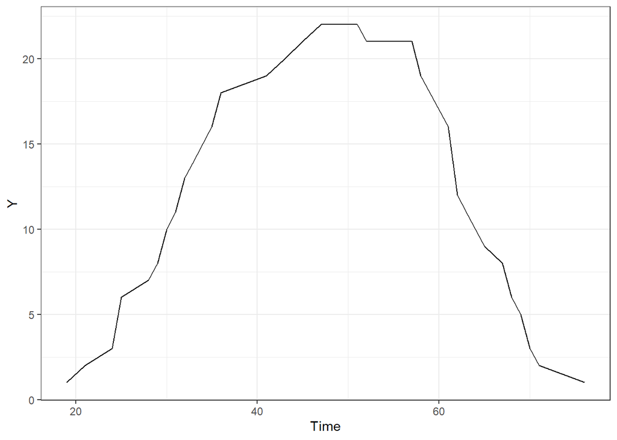

```r
ggplot(table, aes(x=Time, y=Y)) +
  geom_line() + theme_bw()
```

### (b)

Estimate the conditional survival function for a psychiatric patient who has survived to age 30 without entering a psychiatric hospital.

```r
df$death[which(df$age<30)]<-0

Y <- lapply(as.list(min(c(df$age, df$end)):max(c(df$age, df$end))),
            function(x){length(which(df$age<=x)) -
                length(which(df$end<x))}) %>% unlist()
N <- lapply(as.list(min(c(df$age, df$end)):max(c(df$age, df$end))),
            function(x){length(which(df$end<=x & df$death==1))}) %>% unlist()
dN <- diff(c(0,N))

table <- data.frame(Time=min(c(df$age, df$end)):max(c(df$age, df$end)),
                    Y=Y,
                    dN=dN,
                    S=cumprod((Y-dN)/Y))
(table <- table[which(table$Time %in% c(df$age, df$end)), ])
```

```
##    Time  Y dN         S
## 1    19  1  0 1.0000000
## 3    21  2  0 1.0000000
## 6    24  3  0 1.0000000
## 7    25  6  0 1.0000000
## 10   28  7  0 1.0000000
## 11   29  8  0 1.0000000
## 12   30 10  0 1.0000000
## 13   31 11  0 1.0000000
## 14   32 13  0 1.0000000
## 15   33 14  0 1.0000000
## 17   35 16  0 1.0000000
## 18   36 18  0 1.0000000
## 23   41 19  0 1.0000000
## 25   43 20  0 1.0000000
```

[output cut: 20 more lines]

## Q7.2

In Exercise 5 of Chapter 6, the survival experience of patients given an autologous transplant was compared to a postulated exponential survival rate with a hazard rate of 0.045. Using the data in Table 1.4 of Chapter 1, test the hypothesis that the hazard rate of these auto transplant patients is equal to 0.045 against the alternative that it is larger than 0.045 using the one-sample, log-rank test. Repeat this test using a weight function which gives heavier weight to departures early in time from this hazard rate.

```r
data(alloauto)
timevar <- alloauto$time[alloauto$type == 2]
delta   <- alloauto$delta[alloauto$type == 2]

null_surv <- exp(-0.045 * timevar) #Expected survival probability

survdiff(Surv(timevar, delta) ~ offset(null_surv))
```

```
## Call:
## survdiff(formula = Surv(timevar, delta) ~ offset(null_surv))
##
## Observed Expected        Z        p
##  28.0000  38.3992   1.6782   0.0933
```

## Q7.4

In section 1.11, data from a study of the effect of ploidy on survival for patients with tumors of the tongue was reported.

```r
data(tongue)
```

### (a)

Test the hypothesis that the survival rates of patients with cancer of the tongue are the same for patients with aneuploid and diploid tumors using the log-rank test.

```r
survdiff(Surv(time, delta) ~ type, data = tongue, rho = 0)
```

```
## Call:
## survdiff(formula = Surv(time, delta) ~ type, data = tongue, rho = 0)
##
##         N Observed Expected (O-E)^2/E (O-E)^2/V
## type=1 52       31     36.6     0.843      2.79
## type=2 28       22     16.4     1.873      2.79
##
##  Chisq= 2.8  on 1 degrees of freedom, p= 0.09
```

With a p-value = $0.09$, we can not reject the hypothesis that the survival rates of patients with cancer of the tongue are the same for patients with aneuploid and diploid tumors with an $\alpha = 0.05$.

### (b)

If primary interest is in detecting differences in survival rates between the two types of cancers which occur soon after the diagnosis of the cancer, repeat part a using a more appropriate test statistic.

Since we would like to focus on the time soon after the diagnosis of the cancer, we will weight more at the beginning part. Then we chose Peto-Peto weights for comparison.

```r
#Log-Rank Test with Peto-Peto Weight
survdiff(Surv(time, delta) ~ type, data = tongue, rho = 1)
```

```
## Call:
## survdiff(formula = Surv(time, delta) ~ type, data = tongue, rho = 1)
##
##         N Observed Expected (O-E)^2/E (O-E)^2/V
## type=1 52     20.2     24.4     0.731       3.3
## type=2 28     15.1     10.9     1.643       3.3
##
##  Chisq= 3.3  on 1 degrees of freedom, p= 0.07
```

With a p-value = $0.07$, we can not reject the hypothesis that the survival rates of patients with cancer of the tongue are the same for patients with aneuploid and diploid tumors with an $\alpha = 0.05$ and more weighting at time period soon after the diagnosis of the cancer.

## Q7.9

On our web page, data is reported on the death times of 863 kidney transplant patients (see section 1.7). Here, patients can be classified by race and sex into one of four groups

### (a)

Test the hypothesis that there is no difference in survival between the four groups.

```r
data(kidtran)
survdiff(Surv(time, delta) ~ gender+race, data = kidtran, rho = 0)
```

```
## Call:
## survdiff(formula = Surv(time, delta) ~ gender + race, data = kidtran,
##     rho = 0)
##
##                    N Observed Expected (O-E)^2/E (O-E)^2/V
## gender=1, race=1 432       73    69.25    0.2025    0.4013
## gender=1, race=2  92       14    14.52    0.0184    0.0205
## gender=2, race=1 280       39    47.39    1.4860    2.2531
## gender=2, race=2  59       14     8.84    3.0173    3.2245
##
##  Chisq= 4.7  on 3 degrees of freedom, p= 0.2
```

With a p-value = $0.2$, we can not reject the hypothesis that there is no difference in survival between the four groups with an $\alpha = 0.05$.